# Peloton Progress Report

### Performance

💪 😄

Here is how your average output is trending over time:

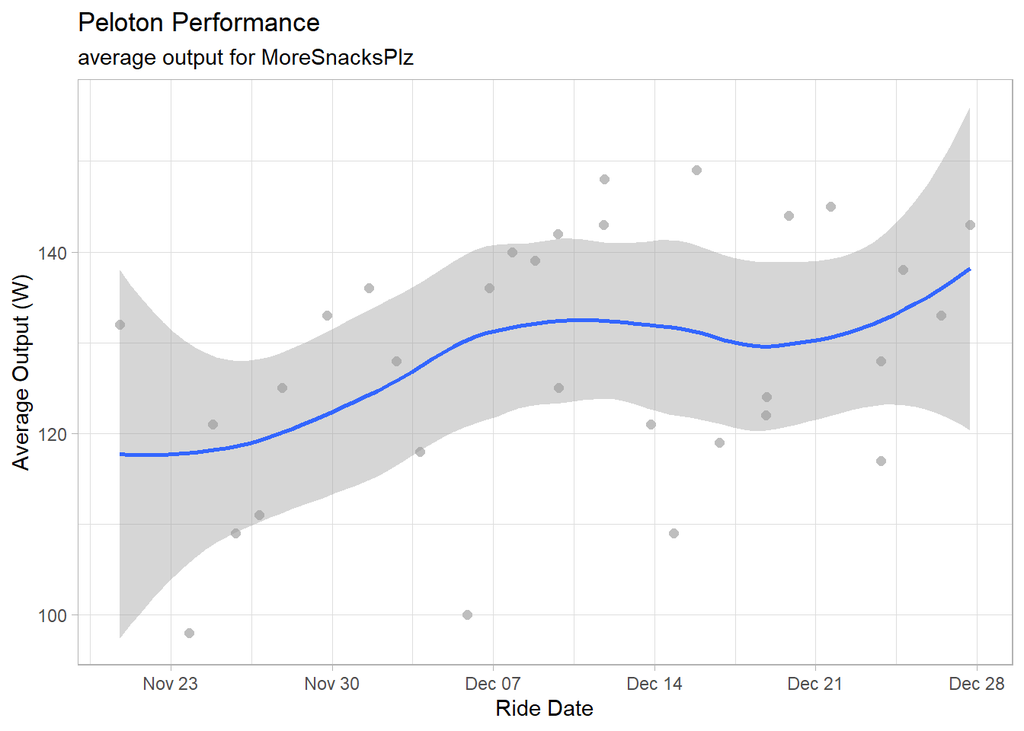

#### Average output by day of the week

Grey dots represent individual workouts, with the darker dots representing the average for that day of the week

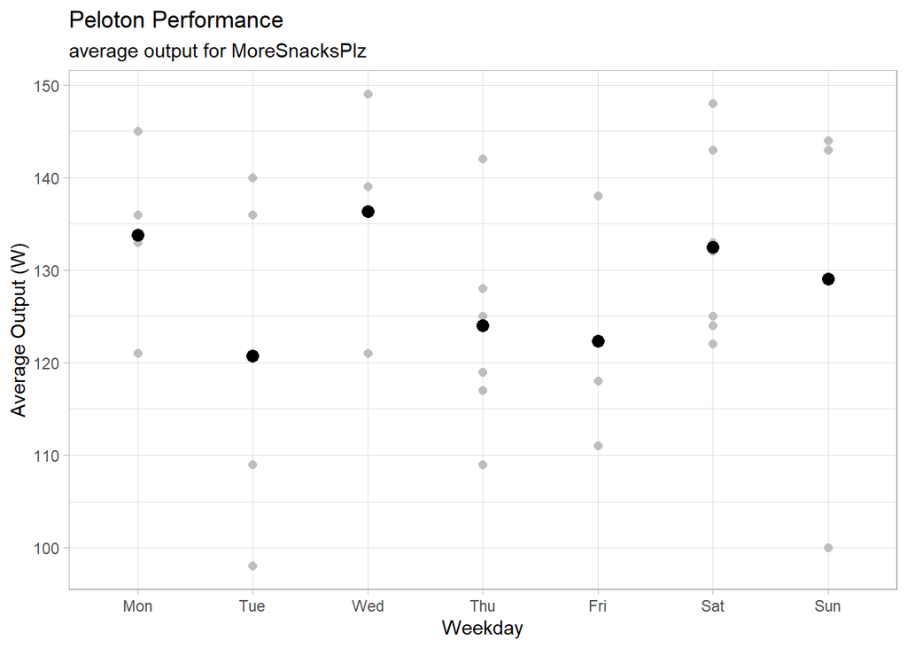

#### Who pushes you the hardest?

In classes over 20 minutes long, **Ally Love** pushes you the hardest! Your output is **142 W** in their classes!

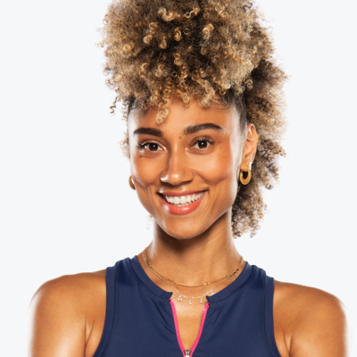

| Instructor |  | Classes over 20 mins | Average Output |
| --- | --- | --- | --- |
|  | Ally Love | 1 | 142 |
|  | Alex & Tunde | 1 | 140 |
|  | Denis Morton | 4 | 136 |
|  | Alex Toussaint | 5 | 133 |
|  | Tunde Oyeneyin | 2 | 133 |
|  | Kendall Toole | 1 | 132 |
|  | Hannah Frankson | 3 | 127 |
|  | Olivia Amato | 2 | 126 |
|  | Emma Lovewell | 1 | 124 |
|  | Cody Rigsby | 10 | 121 |

[output cut: 1 more lines]

### Schedule

⏳

Here is how much time you have spent on the bike on days you worked out:

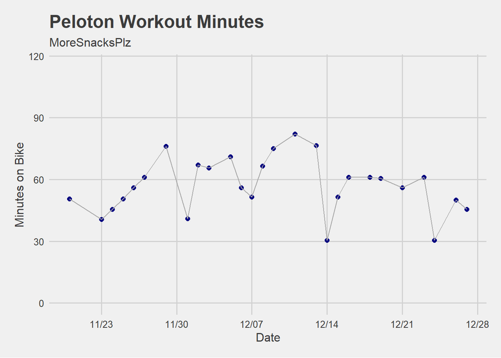

[interactive chart not shown]

[via GIPHY](https://giphy.com/gifs/onepeloton-SwS7xJCrjtwYyUgD1P)

### That’s all for now!

Made by Christian Dittmeier using RMarkdown and the pelotonR package provided by bweiher on Github